# Supporting items for NTA Conference Paper

Published

November 12, 2026

## Manuscript to dissertation crosswalk

Page numbers refer to the June 29 dissertation’s printed table and figure lists. A source correspondence does not certify identical samples or estimates across document versions. Main table values remain in the manuscript; they are not regenerated by this supplementary file.

| Item in manuscript | Subject | Original dissertation item | Location |
| --- | --- | --- | --- |
| Figure 1 | FIRM effective dates | Figure 1, p. 16 | Main text |
| Table 1 | Treated sales by cohort and direction | Table I, p. 29 | Main text |
| Table 2 | Treatment and control groups | Table II, p. 33 | Main text |
| Table 3 | Descriptive statistics | Table III, p. 34 | Main text |
| Table 4 | Selected FEMA estimates | Selected results from Tables V–VI, IX and XI–XII, pp. 43–56 | Main text |
| Table 5 | Conventional TWFE spatial comparisons | Table XIII, p. 59; attached manuscript contains a later version | Main text |
| Table 6 | Extended TWFE spatial comparisons | Table XIV, p. 60; attached manuscript contains a later version | Main text |
| Table 7 | High Flood Factor combined indicator | Table XV, p. 75; expanded specification in manuscript | Main text |
| Table 8 | Decomposed base model | Table XVI, p. 76 | Main text |
| Table 9 | Risk-group post-release estimates | Table XVII, p. 77 | Main text |
| Table 10 | Risk and SFHA subgroup estimates | Table XVIII, p. 78 | Main text |
| Table 11 | Pre-treatment joint tests | Table XXII, p. 93 | Appendix A |
| Supplementary Item 1 | FIRM update timeline | Figure 2, p. 18 | Online |
| Supplementary Item 2 | Full Flood Factor interaction coefficients | Table XXVI, p. 107 | Online |
| Supplementary Item 3 | Regional Flood Factor estimates | Table XIX, p. 80 | Online |
| Supplementary Item 4 | Continuous Flood Factor score specification | Table XX, p. 81 | Online |
| Supplementary Item 5 | Flood Factor score categories | Table XXI, p. 82 | Online |
| Supplementary Item 6 | FEMA event studies | Figure 13, p. 92 | Online |
| Supplementary Item 7 | Cohort-time SFHA removal display | Figure 14, p. 94 | Online |
| Supplementary Item 8 | FEMA placebo results | Table XXIII, p. 94 | Online |
| Supplementary Item 9 | Flood Factor descriptive price trends | Figures 19–20, p. 101; Figure 23, p. 104 | Online |
| Supplementary Item 10 | Flood Factor transformation and distributional checks | Figure 21, p. 102; Figure 22, p. 103 | Online |
| Supplementary Item 11 | Flood Factor pre-release slopes | Table XXIV, p. 104 | Online |
| Supplementary Item 12 | Flood Factor placebo and actual event | Table XXV, p. 106 | Online |
| Supplementary Item 13 | Additional FEMA descriptive and distributional checks | Figures 5–7, pp. 36–37; Figures 15–16, pp. 96–97; Figure 18, p. 99 | Online |

## Online supporting items

### Supplementary Item 1 FIRM update timeline

Original dissertation source: Figure 2, p. 18.

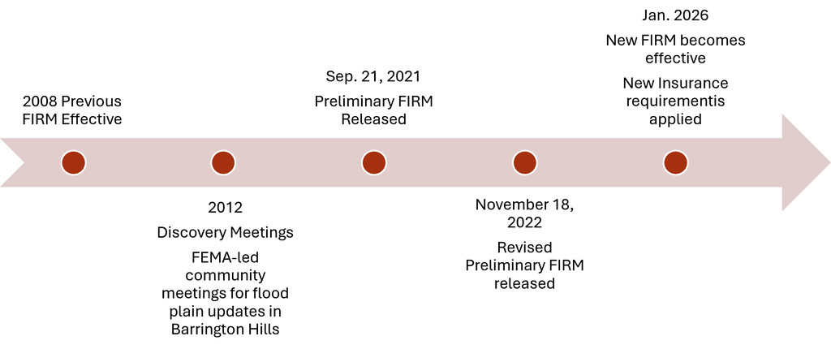

### Supplementary Item 2 Full Flood Factor interaction coefficients

Imports the current full estimated coefficient output, including terms beyond the rounded printed table. Review stable-status versus changer samples.

Source: `docs/q2-text-material.html#q2-full-coefficients`.

## All estimated slope coefficients

Each row below is an estimated slope coefficient from a saved main model, before subgroup marginal-effect aggregation. Absorbed fixed effects and reference categories are not individual rows. Terms removed for collinearity are listed separately; they are not zero estimates. Very large standard errors or confidence intervals are retained rather than silently hidden.

[interactive table not shown]

| Model | Term removed for collinearity |
| --- | --- |
| Post × HighFF | None recorded in saved object |
| Post × HighFF × SFHA | change_typeAlways SFHA |
| Post × HighFF × SFHA | change_typeAlways SFHA:high_ff_scoreTRUE |
| Post × HighFF × SFHA | change_typeChanges SFHA:high_ff_scoreTRUE |
| Post × HighFF × Triad × SFHA | change_typeAlways SFHA |
| Post × HighFF × Triad × SFHA | TriadNorth |
| Post × HighFF × Triad × SFHA | TriadSouth |
| Post × HighFF × Triad × SFHA | change_typeAlways SFHA:high_ff_scoreTRUE |
| Post × HighFF × Triad × SFHA | change_typeChanges SFHA:high_ff_scoreTRUE |
| Post × HighFF × Triad × SFHA | change_typeAlways SFHA:TriadNorth |
| Post × HighFF × Triad × SFHA | change_typeAlways SFHA:TriadSouth |
| Post × HighFF × Triad × SFHA | change_typeChanges SFHA:TriadSouth |
| Post × HighFF × Triad × SFHA | high_ff_scoreTRUE:TriadNorth |
| Post × HighFF × Triad × SFHA | change_typeAlways SFHA:high_ff_scoreTRUE:TriadNorth |
| Post × HighFF × Triad × SFHA | change_typeAlways SFHA:high_ff_scoreTRUE:TriadSouth |
| Post × HighFF × Triad × SFHA | change_typeChanges SFHA:high_ff_scoreTRUE:TriadSouth |
| Post × HighFF × Triad × SFHA | change_typeChanges SFHA:eventTRUE:TriadSouth |
| Post × HighFF × Triad × SFHA | change_typeChanges SFHA:high_ff_scoreTRUE:eventTRUE:TriadSouth |
| Post × HighFF × Triad | TriadNorth |
| Post × HighFF × Triad | TriadSouth |
| Post × HighFF × Triad | high_ff_scoreTRUE:TriadNorth |

### Supplementary Item 3 Regional Flood Factor estimates

The selected current regional marginal-effects table includes standard errors and confidence intervals.

Source: `docs/q2-text-material.html#main-marginal-effects`.

| term | contrast | change_type | Triad | high_ff_score | event | estimate | std.error | conf.low | conf.high | p.value |
| --- | --- | --- | --- | --- | --- | --- | --- | --- | --- | --- |
| event | TRUE - FALSE | Never SFHA | City | FALSE | FALSE | 0.01 | 0.01 | -0.00 | 0.03 | 0.12 |
| event | TRUE - FALSE | Never SFHA | City | TRUE | FALSE | -0.11 | 0.01 | -0.13 | -0.08 | 0.00 |

### Supplementary Item 4 Continuous Flood Factor specifications

Imports the full continuous-score output, including coefficient and marginal-slope variants.

Source: `docs/q2-robustness-FF-variable-forms.html#continuous-flood-factor-models`.

## Continuous Flood Factor Models

With property and year fixed effects, the continuous Flood Factor models do not estimate whether higher-score properties are generally cheaper than lower-score properties. That cross-sectional difference is absorbed by the property fixed effects. Instead, these models test whether post-release price trajectories differed systematically for properties with different Flood Factor scores.

The coefficient on `env_flood_fs_factor:event` is best interpreted as whether properties with higher Flood Factor scores had more negative post-release price changes than properties with lower Flood Factor scores, net of property and year fixed effects.

|  | Continuous | Continuous × Triad | Change Type × Continuous × Event × Triad | Change Type × Continuous × Event |
| --- | --- | --- | --- | --- |
| eventTRUE | 0.080*** | 0.041*** | 0.039*** | 0.081*** |
|  | (0.007) | (0.009) | (0.009) | (0.007) |
| env_flood_fs_factor × eventTRUE | -0.018*** | -0.024*** | -0.022*** | -0.019*** |
|  | (0.002) | (0.002) | (0.002) | (0.002) |
| eventTRUE × TriadNorth |  | -0.051*** | -0.047*** |  |
|  |  | (0.010) | (0.010) |  |
| eventTRUE × TriadSouth |  | 0.157*** | 0.158*** |  |
|  |  | (0.010) | (0.010) |  |
| env_flood_fs_factor × eventTRUE × TriadNorth |  | 0.027*** | 0.021*** |  |
|  |  | (0.003) | (0.004) |  |
| env_flood_fs_factor × eventTRUE × TriadSouth |  | 0.026*** | 0.024*** |  |
|  |  | (0.003) | (0.003) |  |
| change_typeAlways SFHA × eventTRUE |  |  | -0.511*** | -0.003 |
|  |  |  | (0.052) | (0.059) |
| change_typeChanges SFHA × eventTRUE |  |  | -0.099 | 0.024 |
|  |  |  | (0.062) | (0.062) |
| change_typeAlways SFHA × env_flood_fs_factor × eventTRUE |  |  | 0.043*** | 0.002 |
|  |  |  | (0.010) | (0.011) |
| change_typeChanges SFHA × env_flood_fs_factor × eventTRUE |  |  | 0.033 | 0.054** |
|  |  |  | (0.021) | (0.021) |
| change_typeAlways SFHA × eventTRUE × TriadNorth |  |  | 0.622*** |  |
|  |  |  | (0.065) |  |
| change_typeAlways SFHA × eventTRUE × TriadSouth |  |  | 0.539*** |  |
|  |  |  | (0.073) |  |
| change_typeAlways SFHA × env_flood_fs_factor × eventTRUE × TriadNorth |  |  | -0.046*** |  |
|  |  |  | (0.012) |  |
| change_typeAlways SFHA × env_flood_fs_factor × eventTRUE × TriadSouth |  |  | -0.047*** |  |
|  |  |  | (0.013) |  |
| Num.Obs. | 666564 | 666564 | 666564 | 666564 |
| R2 | 0.859 | 0.861 | 0.861 | 0.859 |
| R2 Within | 0.002 | 0.012 | 0.013 | 0.002 |
| Std.Errors | by: pin10 | by: pin10 | by: pin10 | by: pin10 |
| FE: pin | X | X | X | X |
| FE: sale_year | X | X | X | X |

This estimates the post-release marginal association between one additional Flood Factor point and sale price. This is a slope interpretation: it asks whether higher-score properties had more negative post-release price trajectories.

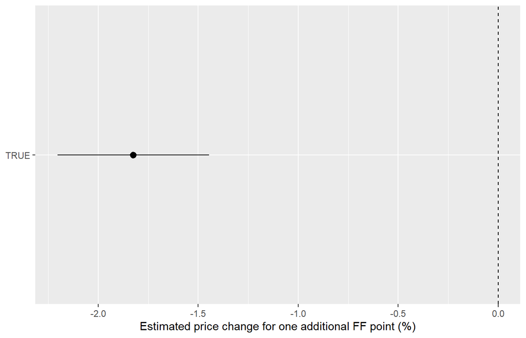

| event | estimate | std.error | conf.low | conf.high | pct_change | pct_low | pct_high | p.value |
| --- | --- | --- | --- | --- | --- | --- | --- | --- |
| TRUE | -0.02 | 0.00 | -0.02 | -0.01 | -1.83 | -2.20 | -1.45 | 0.00 |

This version estimates whether the post-release slope of Flood Factor score differs across Cook County regions.

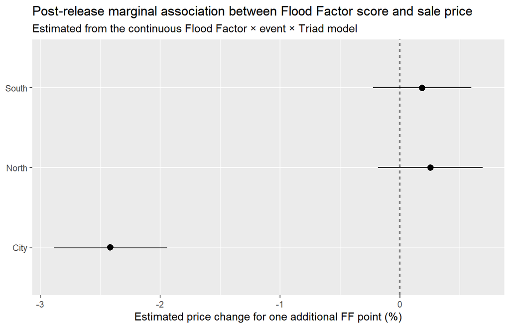

| Triad | estimate | std.error | conf.low | conf.high | pct_change | pct_low | pct_high | p.value |
| --- | --- | --- | --- | --- | --- | --- | --- | --- |
| City | -0.02 | 0.00 | -0.03 | -0.02 | -2.42 | -2.89 | -1.94 | 0.00 |
| North | 0.00 | 0.00 | -0.00 | 0.01 | 0.25 | -0.18 | 0.69 | 0.25 |
| South | 0.00 | 0.00 | -0.00 | 0.01 | 0.19 | -0.22 | 0.60 | 0.38 |

This is not the same estimand as the one-point Flood Factor slope above. This version estimates the post-release contrast at each Flood Factor score and Triad. Use it as a dose-response-style visualization of the information release effect.

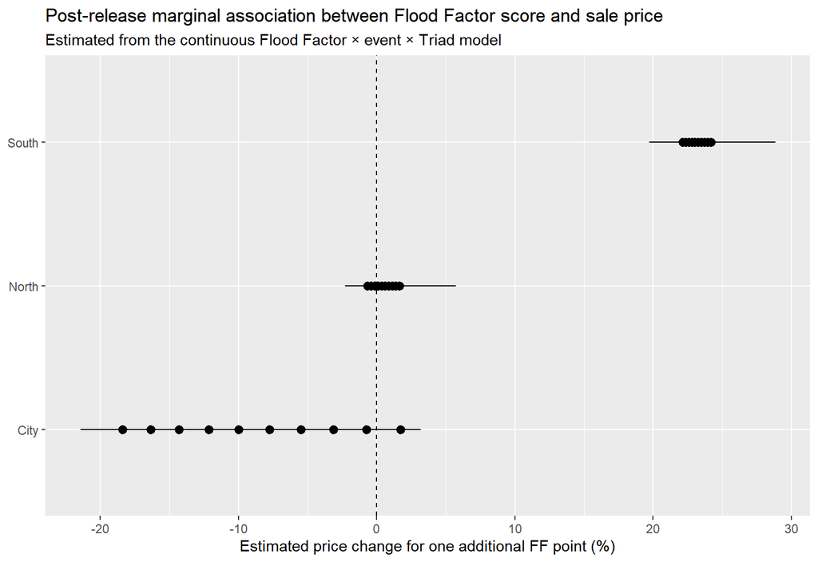

| term | contrast | env_flood_fs_factor | Triad | estimate | std.error | statistic | p.value | s.value | conf.low | conf.high | pct_change | pct_low | pct_high |
| --- | --- | --- | --- | --- | --- | --- | --- | --- | --- | --- | --- | --- | --- |
| event | TRUE - FALSE | 1.00 | City | 0.02 | 0.01 | 2.34 | 0.02 | 5.72 | 0.00 | 0.03 | 1.71 | 0.28 | 3.17 |
| event | TRUE - FALSE | 2.00 | City | -0.01 | 0.01 | -1.18 | 0.24 | 2.07 | -0.02 | 0.00 | -0.75 | -1.97 | 0.50 |
| event | TRUE - FALSE | 3.00 | City | -0.03 | 0.01 | -5.03 | 0.00 | 20.98 | -0.04 | -0.02 | -3.15 | -4.34 | -1.93 |
| event | TRUE - FALSE | 4.00 | City | -0.06 | 0.01 | -7.78 | 0.00 | 46.94 | -0.07 | -0.04 | -5.49 | -6.82 | -4.13 |
| event | TRUE - FALSE | 5.00 | City | -0.08 | 0.01 | -9.21 | 0.00 | 64.72 | -0.10 | -0.06 | -7.77 | -9.35 | -6.17 |
| event | TRUE - FALSE | 6.00 | City | -0.11 | 0.01 | -9.87 | 0.00 | 73.94 | -0.13 | -0.08 | -10.00 | -11.86 | -8.10 |
| event | TRUE - FALSE | 7.00 | City | -0.13 | 0.01 | -10.17 | 0.00 | 78.34 | -0.15 | -0.10 | -12.18 | -14.35 | -9.95 |
| event | TRUE - FALSE | 8.00 | City | -0.15 | 0.01 | -10.31 | 0.00 | 80.36 | -0.18 | -0.12 | -14.30 | -16.78 | -11.75 |
| event | TRUE - FALSE | 9.00 | City | -0.18 | 0.02 | -10.37 | 0.00 | 81.22 | -0.21 | -0.14 | -16.37 | -19.15 | -13.50 |
| event | TRUE - FALSE | 10.00 | City | -0.20 | 0.02 | -10.38 | 0.00 | 81.50 | -0.24 | -0.16 | -18.39 | -21.46 | -15.20 |
| event | TRUE - FALSE | 1.00 | North | -0.01 | 0.01 | -0.98 | 0.33 | 1.61 | -0.02 | 0.01 | -0.65 | -1.95 | 0.66 |
| event | TRUE - FALSE | 2.00 | North | -0.00 | 0.01 | -0.60 | 0.55 | 0.86 | -0.02 | 0.01 | -0.40 | -1.71 | 0.92 |
| event | TRUE - FALSE | 3.00 | North | -0.00 | 0.01 | -0.20 | 0.84 | 0.25 | -0.02 | 0.01 | -0.15 | -1.59 | 1.32 |
| event | TRUE - FALSE | 4.00 | North | 0.00 | 0.01 | 0.12 | 0.90 | 0.15 | -0.02 | 0.02 | 0.11 | -1.58 | 1.82 |
| event | TRUE - FALSE | 5.00 | North | 0.00 | 0.01 | 0.35 | 0.73 | 0.46 | -0.02 | 0.02 | 0.36 | -1.63 | 2.40 |
| event | TRUE - FALSE | 6.00 | North | 0.01 | 0.01 | 0.51 | 0.61 | 0.71 | -0.02 | 0.03 | 0.62 | -1.73 | 3.02 |
| event | TRUE - FALSE | 7.00 | North | 0.01 | 0.01 | 0.62 | 0.53 | 0.91 | -0.02 | 0.04 | 0.87 | -1.85 | 3.67 |
| event | TRUE - FALSE | 8.00 | North | 0.01 | 0.02 | 0.70 | 0.48 | 1.06 | -0.02 | 0.04 | 1.13 | -1.98 | 4.34 |
| event | TRUE - FALSE | 9.00 | North | 0.01 | 0.02 | 0.77 | 0.44 | 1.17 | -0.02 | 0.05 | 1.39 | -2.12 | 5.03 |
| event | TRUE - FALSE | 10.00 | North | 0.02 | 0.02 | 0.81 | 0.42 | 1.26 | -0.02 | 0.06 | 1.65 | -2.28 | 5.72 |
| event | TRUE - FALSE | 1.00 | South | 0.20 | 0.01 | 28.92 | 0.00 | 608.57 | 0.19 | 0.21 | 22.14 | 20.49 | 23.80 |
| event | TRUE - FALSE | 2.00 | South | 0.20 | 0.01 | 29.58 | 0.00 | 636.47 | 0.19 | 0.22 | 22.36 | 20.74 | 24.01 |
| event | TRUE - FALSE | 3.00 | South | 0.20 | 0.01 | 27.71 | 0.00 | 559.10 | 0.19 | 0.22 | 22.59 | 20.84 | 24.37 |
| event | TRUE - FALSE | 4.00 | South | 0.21 | 0.01 | 24.53 | 0.00 | 438.89 | 0.19 | 0.22 | 22.82 | 20.82 | 24.85 |
| event | TRUE - FALSE | 5.00 | South | 0.21 | 0.01 | 21.26 | 0.00 | 330.77 | 0.19 | 0.23 | 23.04 | 20.71 | 25.42 |
| event | TRUE - FALSE | 6.00 | South | 0.21 | 0.01 | 18.44 | 0.00 | 249.68 | 0.19 | 0.23 | 23.27 | 20.56 | 26.05 |
| event | TRUE - FALSE | 7.00 | South | 0.21 | 0.01 | 16.13 | 0.00 | 192.07 | 0.19 | 0.24 | 23.50 | 20.37 | 26.71 |
| event | TRUE - FALSE | 8.00 | South | 0.21 | 0.01 | 14.28 | 0.00 | 151.27 | 0.18 | 0.24 | 23.73 | 20.17 | 27.40 |
| event | TRUE - FALSE | 9.00 | South | 0.21 | 0.02 | 12.79 | 0.00 | 121.94 | 0.18 | 0.25 | 23.96 | 19.94 | 28.11 |
| event | TRUE - FALSE | 10.00 | South | 0.22 | 0.02 | 11.57 | 0.00 | 100.38 | 0.18 | 0.25 | 24.19 | 19.71 | 28.83 |

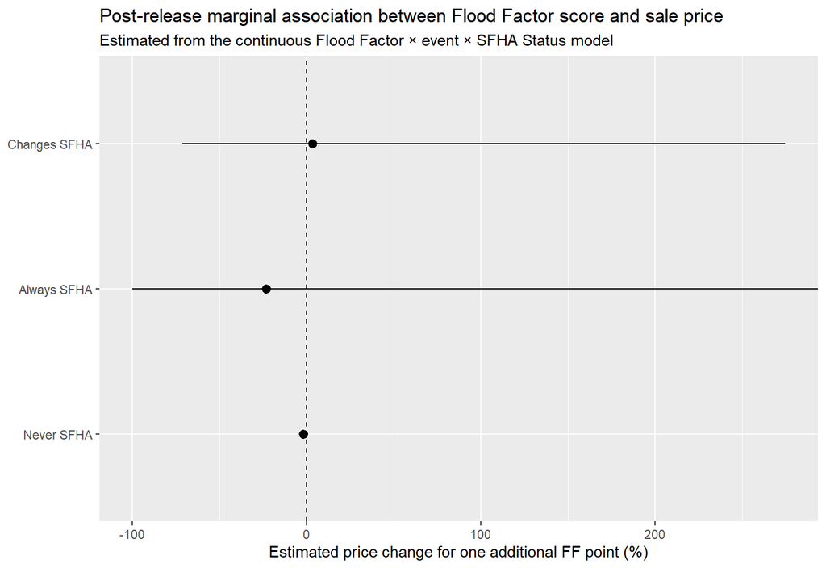

| term | contrast | event | change_type | estimate | std.error | statistic | p.value | s.value | conf.low | conf.high | pct_change | pct_low | pct_high |
| --- | --- | --- | --- | --- | --- | --- | --- | --- | --- | --- | --- | --- | --- |
| env_flood_fs_factor | dY/dX | TRUE | Never SFHA | -0.02 | 0.00 | -9.34 | 0.00 | 66.55 | -0.02 | -0.01 | -1.84 | -2.23 | -1.46 |
| env_flood_fs_factor | dY/dX | TRUE | Always SFHA | -0.26 | 6695.76 | -0.00 | 1.00 | 0.00 | -13123.70 | 13123.18 | -23.16 | -100.00 |  |
| env_flood_fs_factor | dY/dX | TRUE | Changes SFHA | 0.03 | 0.66 | 0.05 | 0.96 | 0.06 | -1.25 | 1.32 | 3.56 | -71.39 | 274.86 |

This model is highly saturated and is best treated as appendix or diagnostic material. It estimates whether the post-release slope of Flood Factor score differs jointly by FEMA SFHA status and region.

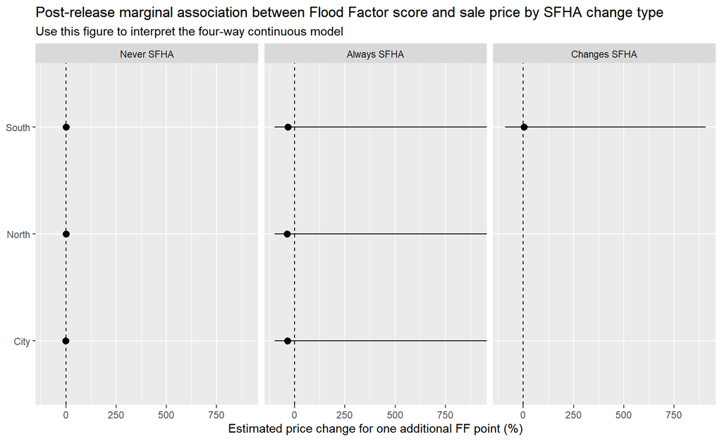

| change_type | Triad | estimate | std.error | conf.low | conf.high | pct_change | pct_low | pct_high | p.value |
| --- | --- | --- | --- | --- | --- | --- | --- | --- | --- |
| Never SFHA | City | -0.02 | 0.00 | -0.03 | -0.02 | -2.18 | -2.66 | -1.70 | 0.00 |
| Never SFHA | North | -0.00 | 0.00 | -0.01 | 0.00 | -0.08 | -0.58 | 0.43 | 0.76 |
| Never SFHA | South | 0.00 | 0.00 | -0.00 | 0.01 | 0.18 | -0.28 | 0.65 | 0.45 |
| Always SFHA | City | -0.43 | 8411.74 | -16487.15 | 16486.28 | -35.21 | -100.00 |  | 1.00 |
| Always SFHA | North | -0.46 | 8411.59 | -16486.87 | 16485.95 | -36.81 | -100.00 |  | 1.00 |
| Always SFHA | South | -0.39 | 10585.78 | -20748.14 | 20747.35 | -32.60 | -100.00 |  | 1.00 |
| Changes SFHA | South | 0.03 | 1.16 | -2.24 | 2.31 | 3.53 | -89.36 | 906.93 | 0.98 |

The following table identifies coefficients omitted from interpretation due to extremely large standard errors or lack of identification under the fixed-effects structure. Large standard errors typically indicate that a coefficient is not identified within the property fixed-effects framework because the underlying variable does not vary within parcels over time, or because certain interaction combinations contain extremely sparse observations.

[interactive table not shown]

### Supplementary Item 5 Flood Factor score categories

Imports categorical-score estimates and associated plots/diagnostics from the ordinal model section. Units and contrast definitions follow the source.

Source: `docs/q2-robustness-FF-variable-forms.html#ordinal-flood-factor-models`.

## Ordinal Flood Factor Models

The ordinal specifications estimate separate post-release effects for each Flood Factor score category. These models are useful for identifying whether the price response is concentrated among higher Flood Factor scores rather than changing linearly across the full scale.

|  | Ordinal | Ordinal × Triad | Change Type × Ordinal × Event × Triad | Change Type × Ordinal × Event |
| --- | --- | --- | --- | --- |
| eventTRUE | 0.061*** | 0.015* | 0.015* | 0.060*** |
|  | (0.006) | (0.008) | (0.008) | (0.006) |
| ff_score_ord2 × eventTRUE | 0.023 | 0.013 | 0.012 | 0.022 |
|  | (0.040) | (0.061) | (0.061) | (0.041) |
| ff_score_ord3 × eventTRUE | -0.028 | -0.030 | -0.031 | -0.030 |
|  | (0.020) | (0.027) | (0.027) | (0.020) |
| ff_score_ord4 × eventTRUE | -0.015 | -0.036 | -0.033 | -0.020 |
|  | (0.019) | (0.027) | (0.027) | (0.020) |
| ff_score_ord5 × eventTRUE | -0.073** | -0.095** | -0.095** | -0.080** |
|  | (0.027) | (0.033) | (0.033) | (0.028) |
| ff_score_ord6 × eventTRUE | -0.118*** | -0.144*** | -0.123*** | -0.108*** |
|  | (0.015) | (0.017) | (0.018) | (0.015) |
| ff_score_ord7 × eventTRUE | -0.068** | -0.101*** | -0.101*** | -0.082*** |
|  | (0.022) | (0.027) | (0.028) | (0.024) |
| ff_score_ord8 × eventTRUE | -0.163*** | -0.154*** | -0.154*** | -0.181*** |
|  | (0.021) | (0.020) | (0.020) | (0.019) |
| ff_score_ord9 × eventTRUE | -0.126*** | -0.163*** | -0.164*** | -0.144*** |
|  | (0.018) | (0.016) | (0.016) | (0.018) |
| ff_score_ord10 × eventTRUE | -0.071+ | -0.217*** | -0.222*** | -0.114* |
|  | (0.038) | (0.041) | (0.041) | (0.045) |
| eventTRUE × TriadNorth |  | -0.020* | -0.021** |  |
|  |  | (0.008) | (0.008) |  |
| eventTRUE × TriadSouth |  | 0.181*** | 0.180*** |  |
|  |  | (0.008) | (0.008) |  |
| ff_score_ord2 × eventTRUE × TriadNorth |  | -0.025 | -0.029 |  |
|  |  | (0.067) | (0.066) |  |
| ff_score_ord3 × eventTRUE × TriadNorth |  | -0.027 | -0.038 |  |
|  |  | (0.038) | (0.039) |  |
| ff_score_ord4 × eventTRUE × TriadNorth |  | 0.061+ | 0.038 |  |
|  |  | (0.033) | (0.032) |  |

[output cut: 84 more lines]

This version uses the ordinal Flood Factor model and estimates the post-release contrast separately for each Flood Factor score.

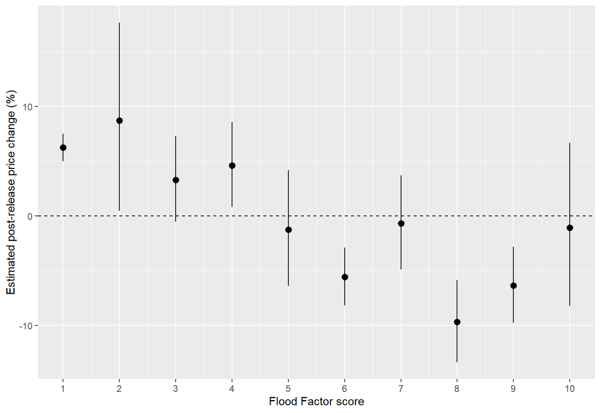

| ff_score_ord | estimate | std.error | conf.low | conf.high | pct_change | pct_low | pct_high | p.value |
| --- | --- | --- | --- | --- | --- | --- | --- | --- |
| 1 | 0.06 | 0.01 | 0.05 | 0.07 | 6.24 | 5.01 | 7.49 | 0.00 |
| 2 | 0.08 | 0.04 | 0.00 | 0.16 | 8.73 | 0.47 | 17.67 | 0.04 |
| 3 | 0.03 | 0.02 | -0.01 | 0.07 | 3.30 | -0.54 | 7.28 | 0.09 |
| 4 | 0.05 | 0.02 | 0.01 | 0.08 | 4.62 | 0.81 | 8.57 | 0.02 |
| 5 | -0.01 | 0.03 | -0.07 | 0.04 | -1.25 | -6.40 | 4.19 | 0.65 |
| 6 | -0.06 | 0.01 | -0.09 | -0.03 | -5.57 | -8.17 | -2.89 | 0.00 |
| 7 | -0.01 | 0.02 | -0.05 | 0.04 | -0.70 | -4.92 | 3.71 | 0.75 |
| 8 | -0.10 | 0.02 | -0.14 | -0.06 | -9.70 | -13.37 | -5.87 | 0.00 |
| 9 | -0.07 | 0.02 | -0.10 | -0.03 | -6.35 | -9.75 | -2.82 | 0.00 |
| 10 | -0.01 | 0.04 | -0.09 | 0.06 | -1.06 | -8.24 | 6.67 | 0.78 |

This version tests whether the ordinal Flood Factor information effect differs by FEMA SFHA status. This is the most relevant robustness check if the core question is whether Flood Factor provided new information beyond FEMA floodplain designation.

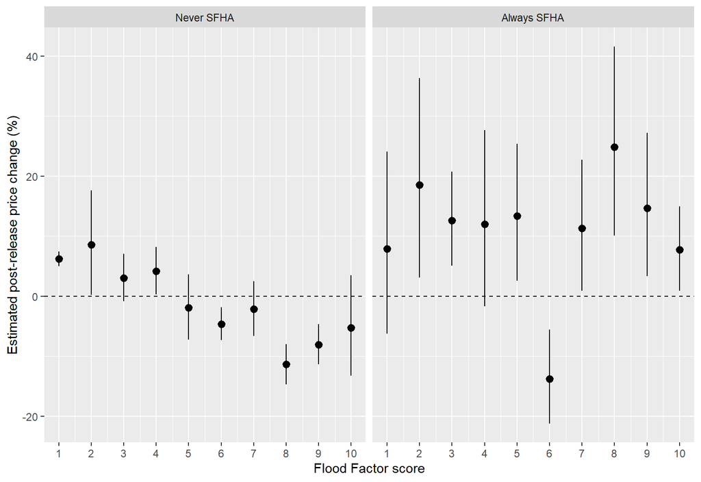

| change_type | ff_score_ord | estimate | std.error | conf.low | conf.high | pct_change | pct_low | pct_high | p.value |
| --- | --- | --- | --- | --- | --- | --- | --- | --- | --- |
| Never SFHA | 1 | 0.06 | 0.01 | 0.05 | 0.07 | 6.21 | 4.98 | 7.47 | 0.00 |
| Never SFHA | 2 | 0.08 | 0.04 | 0.00 | 0.16 | 8.54 | 0.18 | 17.60 | 0.04 |
| Never SFHA | 3 | 0.03 | 0.02 | -0.01 | 0.07 | 3.02 | -0.88 | 7.08 | 0.13 |
| Never SFHA | 4 | 0.04 | 0.02 | 0.00 | 0.08 | 4.15 | 0.25 | 8.20 | 0.04 |
| Never SFHA | 5 | -0.02 | 0.03 | -0.07 | 0.04 | -1.94 | -7.21 | 3.62 | 0.49 |
| Never SFHA | 6 | -0.05 | 0.01 | -0.08 | -0.02 | -4.62 | -7.33 | -1.83 | 0.00 |
| Never SFHA | 7 | -0.02 | 0.02 | -0.07 | 0.02 | -2.18 | -6.63 | 2.49 | 0.35 |
| Never SFHA | 8 | -0.12 | 0.02 | -0.16 | -0.08 | -11.38 | -14.67 | -7.96 | 0.00 |
| Never SFHA | 9 | -0.08 | 0.02 | -0.12 | -0.05 | -8.08 | -11.36 | -4.67 | 0.00 |
| Never SFHA | 10 | -0.05 | 0.05 | -0.14 | 0.03 | -5.28 | -13.28 | 3.47 | 0.23 |
| Always SFHA | 1 | 0.08 | 0.07 | -0.06 | 0.22 | 7.86 | -6.27 | 24.11 | 0.29 |
| Always SFHA | 2 | 0.17 | 0.07 | 0.03 | 0.31 | 18.56 | 3.08 | 36.36 | 0.02 |
| Always SFHA | 3 | 0.12 | 0.04 | 0.05 | 0.19 | 12.61 | 5.06 | 20.71 | 0.00 |
| Always SFHA | 4 | 0.11 | 0.07 | -0.02 | 0.24 | 12.01 | -1.71 | 27.66 | 0.09 |
| Always SFHA | 5 | 0.13 | 0.05 | 0.03 | 0.23 | 13.40 | 2.56 | 25.38 | 0.01 |
| Always SFHA | 6 | -0.15 | 0.05 | -0.24 | -0.06 | -13.75 | -21.24 | -5.55 | 0.00 |
| Always SFHA | 7 | 0.11 | 0.05 | 0.01 | 0.20 | 11.29 | 0.92 | 22.73 | 0.03 |
| Always SFHA | 8 | 0.22 | 0.06 | 0.10 | 0.35 | 24.88 | 10.13 | 41.60 | 0.00 |
| Always SFHA | 9 | 0.14 | 0.05 | 0.03 | 0.24 | 14.66 | 3.33 | 27.23 | 0.01 |
| Always SFHA | 10 | 0.07 | 0.03 | 0.01 | 0.14 | 7.71 | 0.91 | 14.96 | 0.03 |

This version checks whether the ordinal Flood Factor information effect differs across Cook County regions.

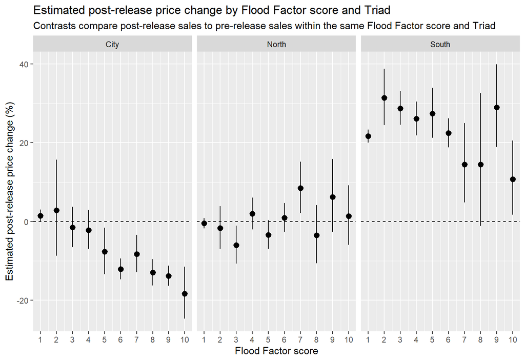

| Triad | ff_score_ord | estimate | std.error | conf.low | conf.high | pct_change | pct_low | pct_high | p.value |
| --- | --- | --- | --- | --- | --- | --- | --- | --- | --- |
| City | 1 | 0.01 | 0.01 | 0.00 | 0.03 | 1.49 | 0.00 | 2.99 | 0.05 |
| City | 2 | 0.03 | 0.06 | -0.09 | 0.15 | 2.81 | -8.65 | 15.71 | 0.65 |
| City | 3 | -0.02 | 0.03 | -0.07 | 0.04 | -1.52 | -6.48 | 3.71 | 0.56 |
| City | 4 | -0.02 | 0.03 | -0.07 | 0.03 | -2.15 | -6.96 | 2.90 | 0.40 |
| City | 5 | -0.08 | 0.03 | -0.14 | -0.02 | -7.69 | -13.41 | -1.60 | 0.01 |
| City | 6 | -0.13 | 0.02 | -0.16 | -0.10 | -12.08 | -14.71 | -9.38 | 0.00 |
| City | 7 | -0.09 | 0.03 | -0.14 | -0.03 | -8.27 | -12.89 | -3.41 | 0.00 |
| City | 8 | -0.14 | 0.02 | -0.18 | -0.10 | -12.96 | -16.23 | -9.57 | 0.00 |
| City | 9 | -0.15 | 0.02 | -0.18 | -0.12 | -13.81 | -16.36 | -11.17 | 0.00 |
| City | 10 | -0.20 | 0.04 | -0.28 | -0.12 | -18.35 | -24.68 | -11.50 | 0.00 |
| North | 1 | -0.00 | 0.01 | -0.02 | 0.01 | -0.48 | -1.79 | 0.84 | 0.47 |
| North | 2 | -0.02 | 0.03 | -0.07 | 0.04 | -1.69 | -6.96 | 3.88 | 0.54 |
| North | 3 | -0.06 | 0.03 | -0.11 | -0.01 | -5.97 | -10.66 | -1.03 | 0.02 |
| North | 4 | 0.02 | 0.02 | -0.02 | 0.06 | 1.99 | -1.97 | 6.10 | 0.33 |
| North | 5 | -0.03 | 0.02 | -0.07 | 0.00 | -3.40 | -6.95 | 0.30 | 0.07 |
| North | 6 | 0.01 | 0.02 | -0.03 | 0.05 | 0.96 | -2.65 | 4.71 | 0.61 |
| North | 7 | 0.08 | 0.03 | 0.02 | 0.14 | 8.49 | 2.17 | 15.20 | 0.01 |
| North | 8 | -0.04 | 0.04 | -0.11 | 0.04 | -3.51 | -10.64 | 4.18 | 0.36 |
| North | 9 | 0.06 | 0.04 | -0.03 | 0.15 | 6.22 | -2.61 | 15.86 | 0.17 |
| North | 10 | 0.01 | 0.04 | -0.06 | 0.09 | 1.37 | -5.88 | 9.18 | 0.72 |
| South | 1 | 0.20 | 0.01 | 0.18 | 0.21 | 21.64 | 20.00 | 23.31 | 0.00 |
| South | 2 | 0.27 | 0.03 | 0.22 | 0.33 | 31.41 | 24.43 | 38.78 | 0.00 |
| South | 3 | 0.25 | 0.02 | 0.22 | 0.29 | 28.74 | 24.52 | 33.10 | 0.00 |
| South | 4 | 0.23 | 0.02 | 0.20 | 0.27 | 26.07 | 21.84 | 30.45 | 0.00 |
| South | 5 | 0.24 | 0.03 | 0.19 | 0.29 | 27.40 | 21.21 | 33.92 | 0.00 |
| South | 6 | 0.20 | 0.02 | 0.17 | 0.23 | 22.47 | 18.85 | 26.21 | 0.00 |
| South | 7 | 0.14 | 0.04 | 0.05 | 0.22 | 14.45 | 4.81 | 24.98 | 0.00 |
| South | 8 | 0.14 | 0.08 | -0.01 | 0.28 | 14.49 | -1.17 | 32.64 | 0.07 |
| South | 9 | 0.25 | 0.04 | 0.17 | 0.34 | 28.97 | 18.90 | 39.91 | 0.00 |
| South | 10 | 0.10 | 0.04 | 0.02 | 0.19 | 10.72 | 1.69 | 20.56 | 0.02 |

This model is highly saturated and is best treated as appendix or diagnostic material. It checks whether the ordinal Flood Factor information effect varies jointly by FEMA SFHA status and Cook County region.

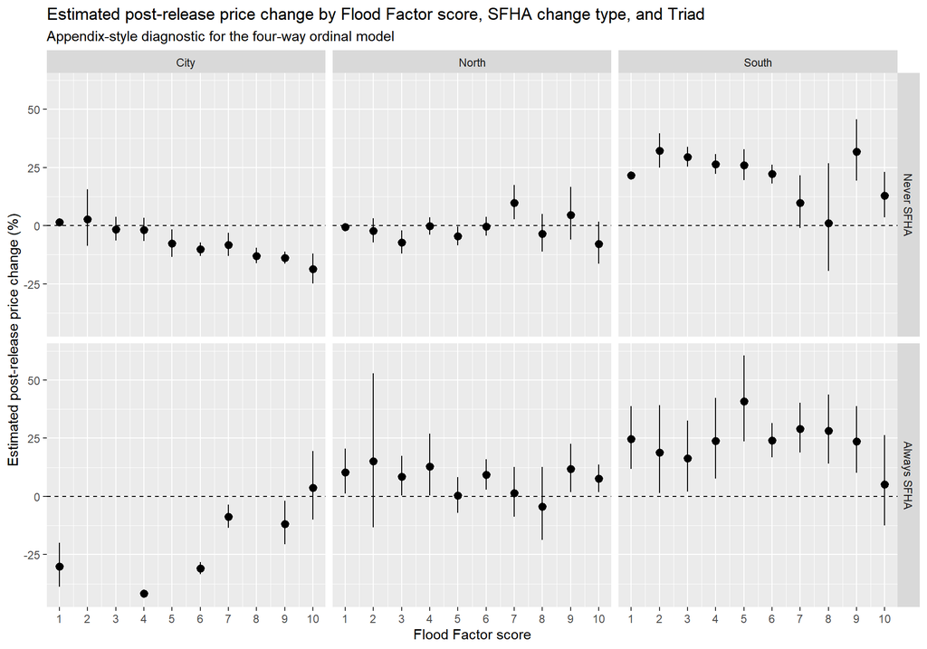

| change_type | Triad | ff_score_ord | estimate | std.error | conf.low | conf.high | pct_change | pct_low | pct_high | p.value |
| --- | --- | --- | --- | --- | --- | --- | --- | --- | --- | --- |
| Never SFHA | City | 1 | 0.02 | 0.01 | 0.00 | 0.03 | 1.52 | 0.03 | 3.03 | 0.05 |
| Never SFHA | City | 2 | 0.03 | 0.06 | -0.09 | 0.15 | 2.79 | -8.67 | 15.68 | 0.65 |
| Never SFHA | City | 3 | -0.02 | 0.03 | -0.07 | 0.04 | -1.54 | -6.50 | 3.69 | 0.56 |
| Never SFHA | City | 4 | -0.02 | 0.03 | -0.07 | 0.03 | -1.78 | -6.63 | 3.31 | 0.49 |
| Never SFHA | City | 5 | -0.08 | 0.03 | -0.14 | -0.02 | -7.71 | -13.42 | -1.62 | 0.01 |
| Never SFHA | City | 6 | -0.11 | 0.02 | -0.14 | -0.08 | -10.19 | -13.01 | -7.27 | 0.00 |
| Never SFHA | City | 7 | -0.09 | 0.03 | -0.14 | -0.03 | -8.26 | -13.14 | -3.11 | 0.00 |
| Never SFHA | City | 8 | -0.14 | 0.02 | -0.18 | -0.10 | -12.98 | -16.25 | -9.59 | 0.00 |
| Never SFHA | City | 9 | -0.15 | 0.02 | -0.18 | -0.12 | -13.86 | -16.45 | -11.19 | 0.00 |
| Never SFHA | City | 10 | -0.21 | 0.04 | -0.29 | -0.13 | -18.69 | -24.90 | -11.97 | 0.00 |
| Never SFHA | North | 1 | -0.01 | 0.01 | -0.02 | 0.01 | -0.63 | -1.93 | 0.69 | 0.35 |
| Never SFHA | North | 2 | -0.02 | 0.03 | -0.08 | 0.03 | -2.24 | -7.33 | 3.12 | 0.41 |
| Never SFHA | North | 3 | -0.07 | 0.03 | -0.13 | -0.02 | -7.19 | -12.00 | -2.12 | 0.01 |
| Never SFHA | North | 4 | -0.00 | 0.02 | -0.04 | 0.04 | -0.19 | -3.86 | 3.62 | 0.92 |
| Never SFHA | North | 5 | -0.05 | 0.02 | -0.09 | -0.00 | -4.53 | -8.53 | -0.36 | 0.03 |
| Never SFHA | North | 6 | -0.00 | 0.02 | -0.04 | 0.04 | -0.34 | -4.22 | 3.71 | 0.87 |
| Never SFHA | North | 7 | 0.09 | 0.03 | 0.03 | 0.16 | 9.77 | 2.67 | 17.37 | 0.01 |
| Never SFHA | North | 8 | -0.03 | 0.04 | -0.12 | 0.05 | -3.40 | -11.23 | 5.11 | 0.42 |
| Never SFHA | North | 9 | 0.05 | 0.06 | -0.06 | 0.15 | 4.69 | -6.06 | 16.68 | 0.41 |
| Never SFHA | North | 10 | -0.08 | 0.05 | -0.18 | 0.02 | -7.77 | -16.33 | 1.67 | 0.10 |
| Never SFHA | South | 1 | 0.20 | 0.01 | 0.18 | 0.21 | 21.60 | 19.95 | 23.26 | 0.00 |
| Never SFHA | South | 2 | 0.28 | 0.03 | 0.22 | 0.33 | 32.10 | 24.87 | 39.76 | 0.00 |
| Never SFHA | South | 3 | 0.26 | 0.02 | 0.23 | 0.29 | 29.60 | 25.40 | 33.95 | 0.00 |
| Never SFHA | South | 4 | 0.23 | 0.02 | 0.20 | 0.27 | 26.35 | 22.20 | 30.65 | 0.00 |
| Never SFHA | South | 5 | 0.23 | 0.03 | 0.18 | 0.28 | 26.02 | 19.50 | 32.91 | 0.00 |
| Never SFHA | South | 6 | 0.20 | 0.02 | 0.17 | 0.23 | 22.14 | 18.16 | 26.26 | 0.00 |
| Never SFHA | South | 7 | 0.09 | 0.05 | -0.01 | 0.20 | 9.71 | -1.03 | 21.62 | 0.08 |
| Never SFHA | South | 8 | 0.01 | 0.12 | -0.22 | 0.24 | 0.99 | -19.53 | 26.74 | 0.93 |
| Never SFHA | South | 9 | 0.28 | 0.05 | 0.18 | 0.38 | 31.87 | 19.35 | 45.70 | 0.00 |
| Never SFHA | South | 10 | 0.12 | 0.04 | 0.03 | 0.21 | 12.83 | 3.47 | 23.03 | 0.01 |
| Always SFHA | City | 1 | -0.36 | 0.07 | -0.49 | -0.22 | -30.09 | -38.91 | -20.00 | 0.00 |
| Always SFHA | City | 4 | -0.54 | 0.01 | -0.55 | -0.53 | -41.77 | -42.50 | -41.04 | 0.00 |
| Always SFHA | City | 6 | -0.37 | 0.02 | -0.41 | -0.33 | -30.88 | -33.45 | -28.21 | 0.00 |
| Always SFHA | City | 7 | -0.09 | 0.03 | -0.14 | -0.04 | -8.70 | -13.49 | -3.65 | 0.00 |
| Always SFHA | City | 9 | -0.13 | 0.05 | -0.23 | -0.02 | -11.82 | -20.68 | -1.96 | 0.02 |
| Always SFHA | City | 10 | 0.04 | 0.07 | -0.11 | 0.18 | 3.66 | -10.05 | 19.46 | 0.62 |
| Always SFHA | North | 1 | 0.10 | 0.04 | 0.01 | 0.19 | 10.40 | 1.17 | 20.48 | 0.03 |
| Always SFHA | North | 2 | 0.14 | 0.14 | -0.14 | 0.42 | 15.12 | -13.27 | 52.81 | 0.33 |
| Always SFHA | North | 3 | 0.08 | 0.04 | 0.00 | 0.16 | 8.57 | 0.33 | 17.48 | 0.04 |
| Always SFHA | North | 4 | 0.12 | 0.06 | 0.00 | 0.24 | 12.84 | 0.28 | 26.97 | 0.04 |
| Always SFHA | North | 5 | 0.00 | 0.04 | -0.07 | 0.08 | 0.35 | -7.08 | 8.37 | 0.93 |
| Always SFHA | North | 6 | 0.09 | 0.03 | 0.03 | 0.15 | 9.28 | 2.91 | 16.03 | 0.00 |
| Always SFHA | North | 7 | 0.01 | 0.05 | -0.09 | 0.12 | 1.35 | -8.76 | 12.59 | 0.80 |
| Always SFHA | North | 8 | -0.04 | 0.08 | -0.21 | 0.12 | -4.38 | -18.81 | 12.61 | 0.59 |
| Always SFHA | North | 9 | 0.11 | 0.05 | 0.02 | 0.20 | 11.69 | 1.84 | 22.49 | 0.02 |
| Always SFHA | North | 10 | 0.07 | 0.03 | 0.02 | 0.13 | 7.62 | 1.91 | 13.65 | 0.01 |
| Always SFHA | South | 1 | 0.22 | 0.06 | 0.11 | 0.33 | 24.59 | 11.82 | 38.81 | 0.00 |
| Always SFHA | South | 2 | 0.17 | 0.08 | 0.01 | 0.33 | 18.81 | 1.39 | 39.22 | 0.03 |
| Always SFHA | South | 3 | 0.15 | 0.07 | 0.02 | 0.28 | 16.39 | 2.12 | 32.65 | 0.02 |
| Always SFHA | South | 4 | 0.21 | 0.07 | 0.07 | 0.35 | 23.75 | 7.56 | 42.38 | 0.00 |
| Always SFHA | South | 5 | 0.34 | 0.07 | 0.21 | 0.47 | 40.85 | 23.58 | 60.52 | 0.00 |
| Always SFHA | South | 6 | 0.21 | 0.03 | 0.16 | 0.27 | 23.95 | 16.80 | 31.52 | 0.00 |
| Always SFHA | South | 7 | 0.26 | 0.04 | 0.17 | 0.34 | 29.07 | 18.80 | 40.22 | 0.00 |
| Always SFHA | South | 8 | 0.25 | 0.06 | 0.13 | 0.36 | 28.11 | 14.14 | 43.80 | 0.00 |
| Always SFHA | South | 9 | 0.21 | 0.06 | 0.10 | 0.33 | 23.57 | 10.12 | 38.68 | 0.00 |
| Always SFHA | South | 10 | 0.05 | 0.09 | -0.13 | 0.23 | 5.20 | -12.45 | 26.41 | 0.59 |

The following table identifies coefficients omitted from interpretation due to extremely large standard errors or lack of identification under the fixed-effects structure. Large standard errors typically indicate that a coefficient is not identified within the property fixed-effects framework because the underlying variable does not vary within parcels over time, or because certain interaction combinations contain extremely sparse observations.

[interactive table not shown]

### Supplementary Item 6 FEMA event studies

Current website sections retain plots, joint-test output and methodological notes for additions and removals.

Source: `docs/q1-text-material.html#q1-added-event-study`.

## Additions: event study and pretrend tests

Properties added to the preliminary SFHA are compared with never-SFHA properties. Event time is relative to the preliminary map year; sales earlier than the preliminary date within that year are assigned to year -1. The endpoint bins pool years at or below -5 and at or above +5. Year -1 is the omitted reference period.

The plotted model uses logged sale price, property and year fixed effects, and standard errors clustered by 10-digit parcel. The coefficient table below the plot lists estimated pretreatment leads; the Wald test jointly tests the included leads -5 through -2 against zero relative to year -1. Rejection raises concerns about the specification or pre-event comparability. Non-rejection is not proof of parallel trends, especially when treated samples are small.

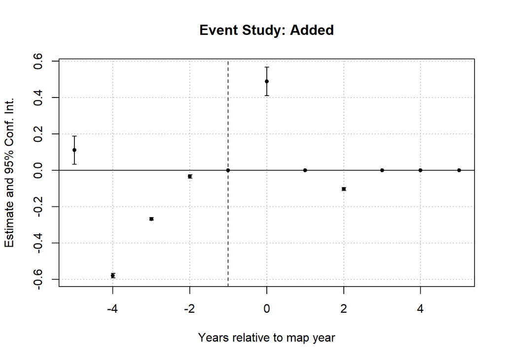

| term | estimate | std.error | statistic | p.value | rel_time |
| --- | --- | --- | --- | --- | --- |
| event_time_binned::-5:treated | 0.1104162 | 0.0395717 | 2.790280 | 0.0052668 | -5 |
| event_time_binned::-4:treated | -0.5796238 | 0.0063581 | -91.162598 | 0.0000000 | -4 |
| event_time_binned::-3:treated | -0.2672640 | 0.0038471 | -69.470805 | 0.0000000 | -3 |
| event_time_binned::-2:treated | -0.0340017 | 0.0048248 | -7.047211 | 0.0000000 | -2 |

```
Wald test, H0: joint nullity of event_time_binned::-5:treated, event_time_binned::-4:treated, event_time_binned::-3:treated and event_time_binned::-2:treated
 stat = 2,874.2, p-value < 2.2e-16, on 4 and 186,108 DoF, VCOV: Clustered (pin10).
```

Source: `docs/q1-text-material.html#q1-removed-event-study`.

## Removals: event study and pretrend tests

Properties removed from the preliminary SFHA are compared with always-SFHA properties. The event-time bins, omitted period, fixed effects, and clustering follow the addition specification. The plot and joint lead test provide the removal-side diagnostics discussed in Appendix A; the appropriate comparison is within this design, rather than between its coefficient levels and those of the addition design.

```
[1] 2010 2025
```

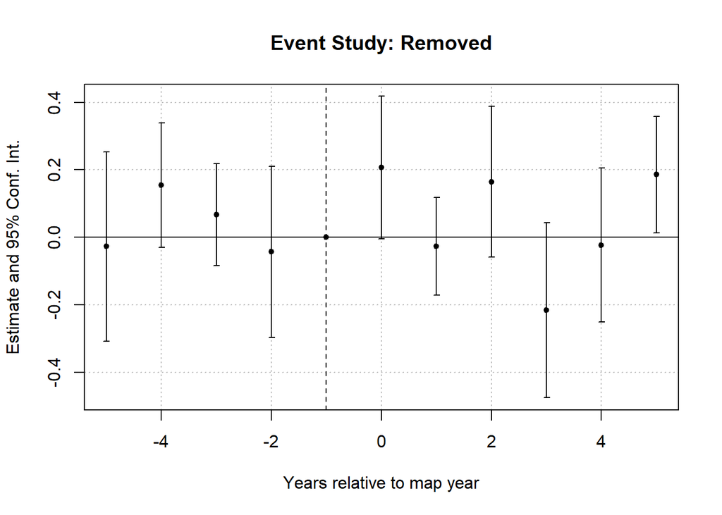

This specification controls for common year effects but does not allow year effects to differ across North Cook, South Cook, and Chicago. The regional-control comparison below examines sensitivity to that restriction; the baseline specification alone does not establish whether regional differences explain its estimates.

| term | estimate | std.error | statistic | p.value | rel_time |
| --- | --- | --- | --- | --- | --- |
| event_time_binned::-5:treated | -0.0272036 | 0.1429671 | -0.1902788 | 0.8491055 | -5 |
| event_time_binned::-4:treated | 0.1548045 | 0.0941084 | 1.6449593 | 0.1000987 | -4 |
| event_time_binned::-3:treated | 0.0670327 | 0.0770443 | 0.8700546 | 0.3843506 | -3 |
| event_time_binned::-2:treated | -0.0432119 | 0.1293224 | -0.3341406 | 0.7383003 | -2 |

```
Wald test, H0: joint nullity of event_time_binned::-5:treated, event_time_binned::-4:treated, event_time_binned::-3:treated and event_time_binned::-2:treated
 stat = 1.16631, p-value = 0.323669, on 4 and 2,609 DoF, VCOV: Clustered (pin10).
```

> Read the joint test as a test that the included pretreatment coefficients are zero relative to the omitted period. It is not a test that the coefficients equal one another, and a non-significant result does not prove parallel trends.

### Supplementary Item 7 Cohort-time FEMA event profiles

Imports the source extended-TWFE event profiles. This is the broader available output, not a claim that every panel is the original Figure 14.

Source: `docs/q1-text-material.html#q1-etwfe-event-profiles`.

## Extended-TWFE event profiles

These existing extended-TWFE models produce grouped marginal effects and event profiles for preliminary-map removals, followed by additions. Each model excludes the opposite transition and uses the corresponding always-SFHA or never-SFHA comparison category. These outputs supplement the binned event studies; different estimators, aggregation, and comparison sets can produce different profiles. The earlier heading associated this output with Figure 12; an exact match to the printed figure has not been established here.

```
 group_name_prelim treat_year_remove_prelim Estimate Std. Error    z Pr(>|z|)
              2015                     2015    0.131     0.0716 1.83   0.0676
              2021                     2021    0.177     0.0316 5.60   <0.001
    S    2.5 % 97.5 %
  3.9 -0.00947  0.271
 25.5  0.11510  0.239

Term: .Dtreat
Type: response
Comparison: TRUE - FALSE
```

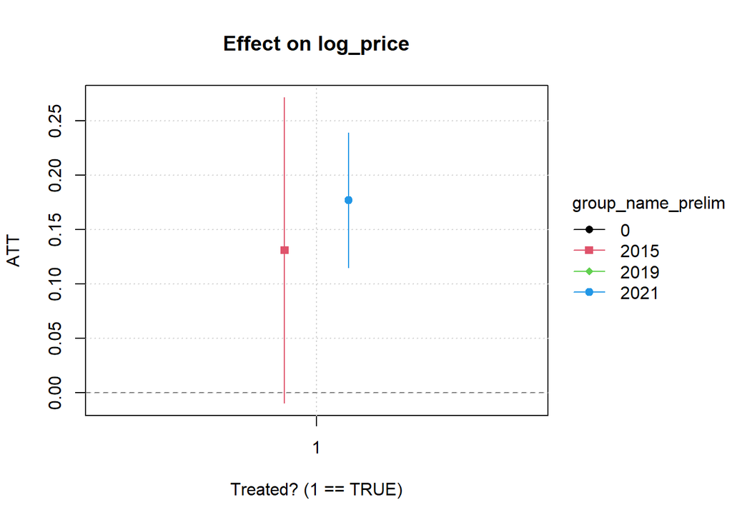

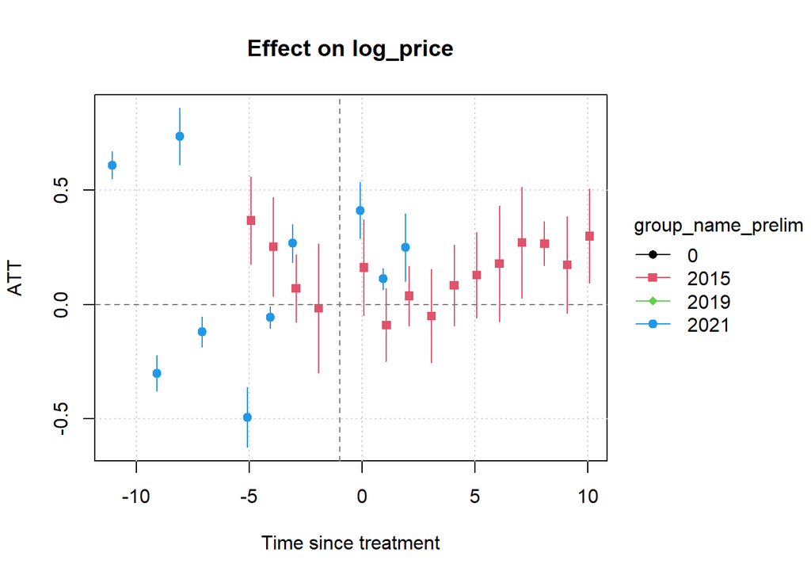

```
 group_name_prelim treat_year_add_prelim Estimate Std. Error     z Pr(>|z|)
              2015                  2015   0.0000         NA    NA       NA
              2021                  2021  -0.0214   0.000881 -24.2   <0.001
     S   2.5 %  97.5 %
    NA      NA      NA
 428.6 -0.0231 -0.0196

Term: .Dtreat
Type: response
Comparison: TRUE - FALSE
```

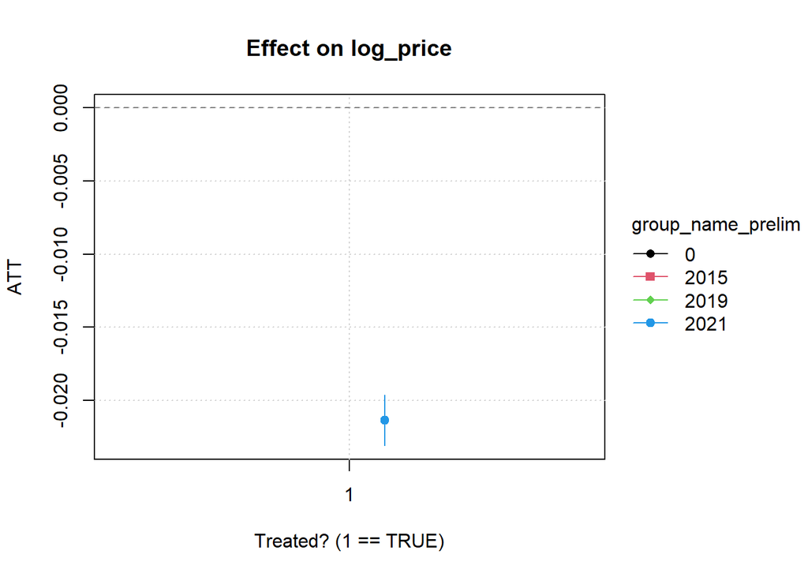

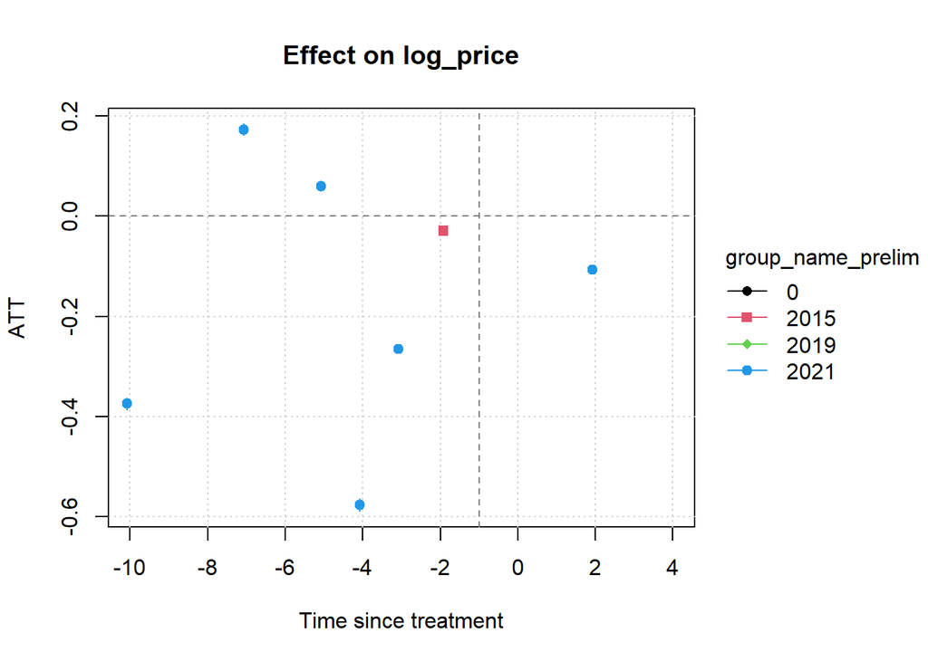

### Supplementary Item 8 FEMA placebo results

Only the first two tables are imported: removals and additions with two-year-early dates. Subsequent actual-date tables in the source section are intentionally not pooled into the placebo exhibit.

Source: `docs/q1-text-material.html#q1-placebo-tests`.

|  | m_placebo |
| --- | --- |
| Dependent Var.: | log_price |
| placebo_postTRUE | -0.1085 (0.1330) |
| treatedTRUE x placebo_postTRUE | -0.1975 (0.1934) |
| Fixed-Effects: | —————- |
| pin | Yes |
| sale_year | Yes |
| ______________________________ | ________________ |
| S.E.: Clustered | by: pin10 |
| Observations | 224 |
| R2 | 0.96363 |
| Within R2 | 0.01679 |

|  | m_placebo |
| --- | --- |
| Dependent Var.: | log_price |
| placebo_postTRUE | 0.0126 (0.0105) |
| treatedTRUE x placebo_postTRUE | 0.3056*** (0.0127) |
| Fixed-Effects: | —————— |
| pin | Yes |
| sale_year | Yes |
| ______________________________ | __________________ |
| S.E.: Clustered | by: pin10 |
| Observations | 64,308 |
| R2 | 0.89959 |
| Within R2 | 6.12e-5 |

### Supplementary Item 9 Flood Factor descriptive price trends

Historical rendered Quarto figures: high-risk groups in levels/logs, plus SFHA groups in levels. Read legends for grouping. The newer saved-plot render failed; these older images are used explicitly as historical outputs.

Source plot: q2_assumption_graphs_files/figure-html/unnamed-chunk-7-1.png

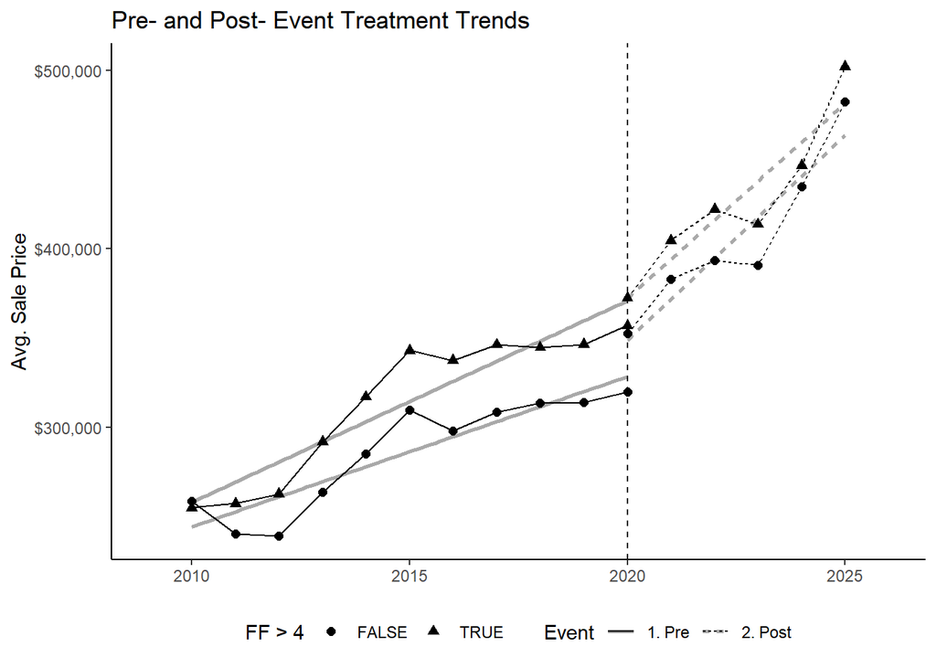

Source plot: q2_assumption_graphs_files/figure-html/unnamed-chunk-7-2.png

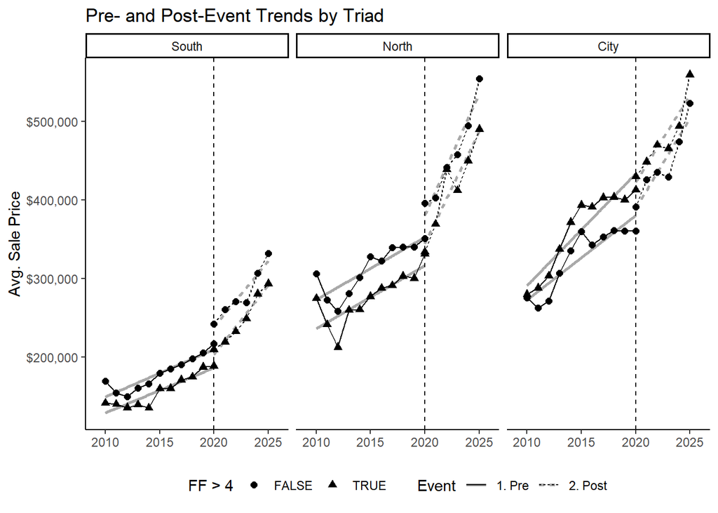

Source plot: q2_assumption_graphs_files/figure-html/unnamed-chunk-8-1.png

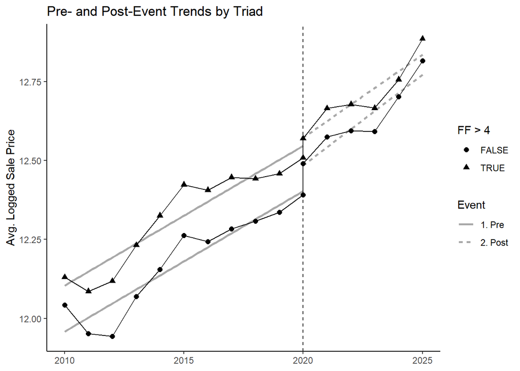

Source plot: q2_assumption_graphs_files/figure-html/unnamed-chunk-8-2.png

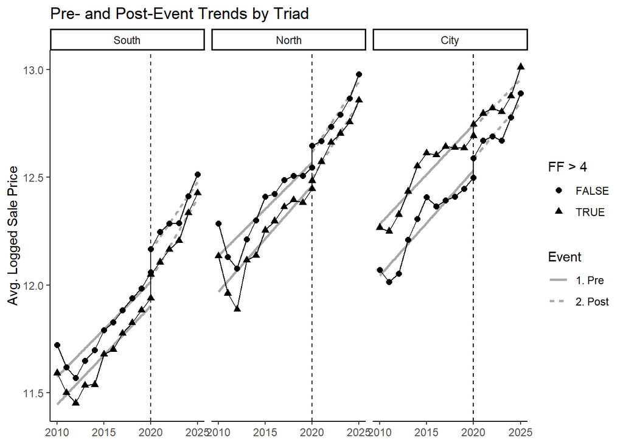

Source plot: q2_assumption_graphs_files/figure-html/unnamed-chunk-10-1.png

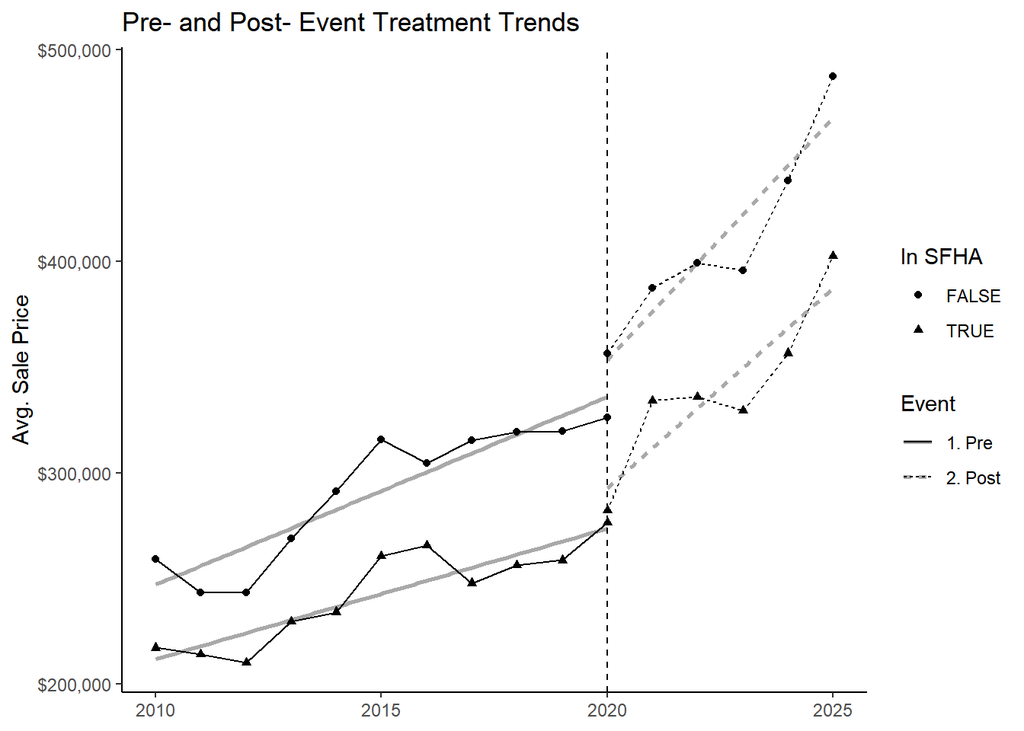

Source plot: q2_assumption_graphs_files/figure-html/unnamed-chunk-10-2.png

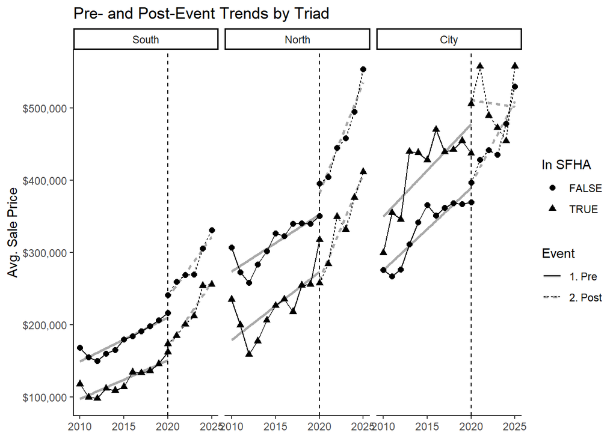

### Supplementary Item 10 Flood Factor transformations and distributional checks

Historical inverse-price and SFHA asinh plots supplement Item 9. The SFHA asinh panels are not the same risk-group caption as dissertation Figure 21. Current distributional-source text supplies provenance and p-values; a NULL plot result is left visible as an unresolved output issue.

Source plot: q2_assumption_graphs_files/figure-html/unnamed-chunk-9-1.png

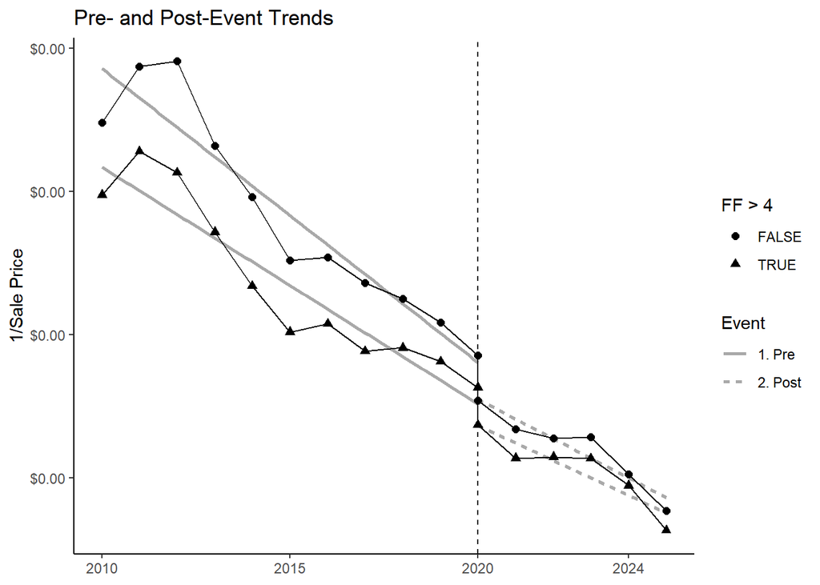

Source plot: q2_assumption_graphs_files/figure-html/unnamed-chunk-9-2.png

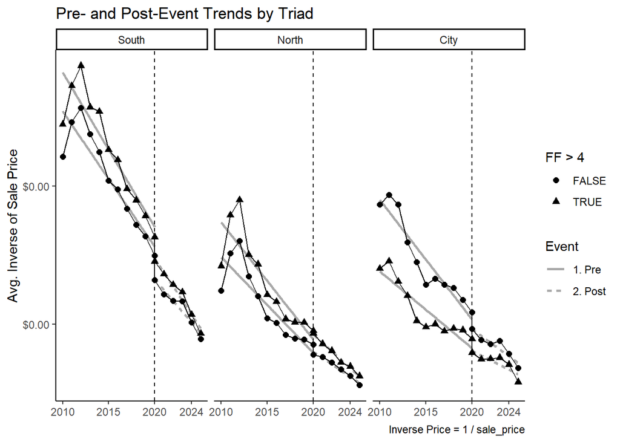

Source plot: q2_assumption_graphs_files/figure-html/unnamed-chunk-12-3.png

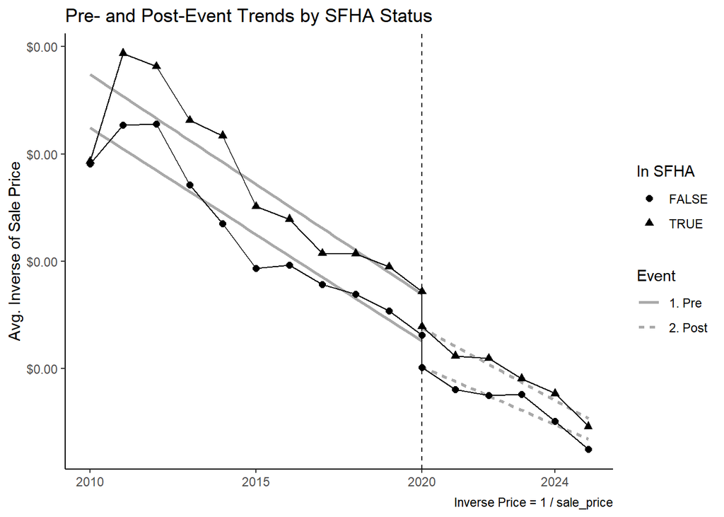

Source plot: q2_assumption_graphs_files/figure-html/unnamed-chunk-12-4.png

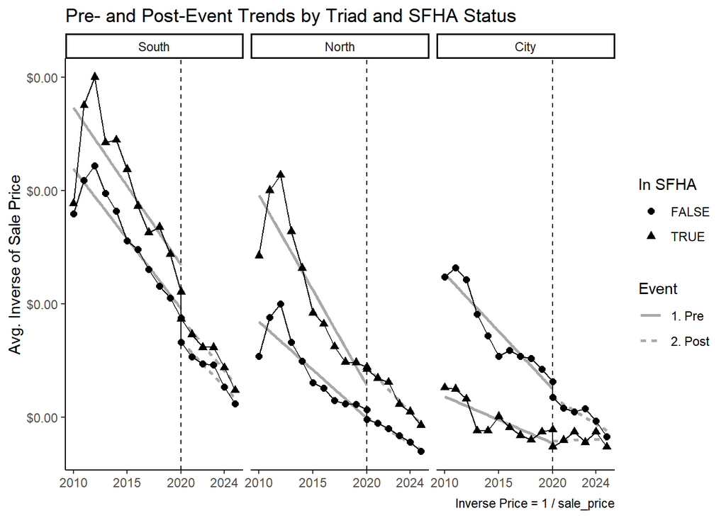

Source plot: q2_assumption_graphs_files/figure-html/unnamed-chunk-13-1.png

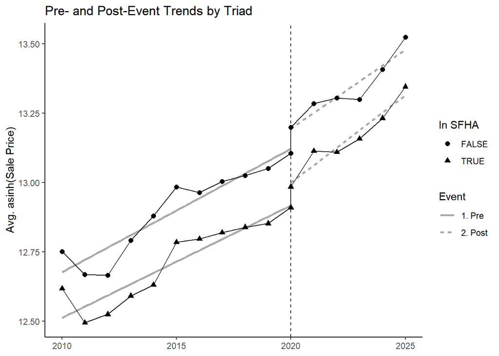

Source plot: q2_assumption_graphs_files/figure-html/unnamed-chunk-13-2.png

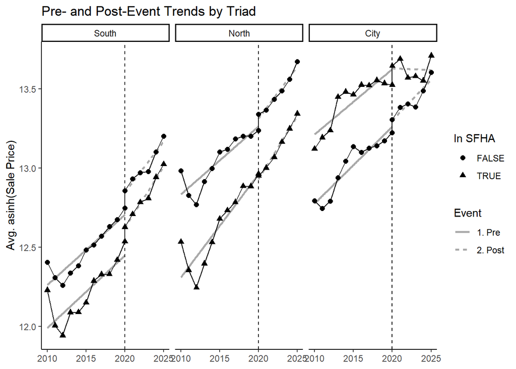

Source: `docs/q2-text-material.html#q2-distributional-tests`.

## Distributional diagnostics and anticipation

The saved distributional diagnostics come from `scripts/Q2_FloodFactor_didFF_test.R`. That script uses the older `data/processed/df_prep_buildings.rds` input, applies its missing-data and parcel filters, averages observations within property-year, and assigns the treated group to 2020 for a property with a high Flood Factor score and an observed post-release sale. The last condition makes group assignment depend on observed sales as well as risk status. This historical construction must be reviewed before treating these outputs as a definitive check of the current main model.

The logged and unlogged saved objects both report p-values of 1. The displays below load those results without rerunning the exploratory script. They are not evidence that the current main-model sample passes every identifying assumption: failure to reject a distributional diagnostic does not prove mean parallel trends, absence of anticipation, or causal identification.

```
Logged sale price: historical Q2 diagnostic
Saved p-value: 1
NULL

Sale price: historical Q2 diagnostic
Saved p-value: 1
NULL
```

### What the anticipation checks can establish

The pre-event slope tests and the pre-2020 placebo sample address patterns before the recorded Flood Factor release. The existing placebo code defines its post period as years greater than 2017, so 2018-2019 are post-placebo and 2017 itself remains pre-placebo. A significant placebo interaction may reflect differential trends, other events, or anticipation; it does not distinguish among them. A non-significant result cannot rule out advance information or limited power. The assumed information date and sample construction must be considered alongside these diagnostics.

### Supplementary Item 11 Flood Factor pre-release slope tests

The current section contains multiple specifications and regional tests, with source descriptions of outcome scale and controls. These are not all the same model as the printed Table XXIV.

Source: `docs/q2-text-material.html#q2-pretrend-tests`.

## Pre-event slope tests

The first tables examine linear slope differences by SFHA and high Flood Factor status in sales before 2020, with parcel-clustered standard errors but no property fixed effects. Subsequent specifications use the recorded release date and include property/year fixed effects or split the comparison by triad, as labeled. These are different specifications and pre-period definitions. A non-significant interaction does not establish equivalence of trends; inspect its magnitude and precision as well as the p-value.

Pre-event slope tests

|  | SFHA × time | HighFF × time | SFHA×HighFF × time |
| --- | --- | --- | --- |
| (Intercept) | -79.755*** | -79.809*** | -79.488*** |
|  | (1.379) | (1.480) | (1.481) |
| sale_year | 0.046*** | 0.046*** | 0.045*** |
|  | (0.001) | (0.001) | (0.001) |
| in_eff_sfhaTRUE | 8.126 |  | -23.496 |
|  | (11.878) |  | (14.752) |
| sale_year × in_eff_sfhaTRUE | -0.004 |  | 0.011 |
|  | (0.006) |  | (0.007) |
| high_ff_scoreTRUE |  | 0.057 | -3.149 |
|  |  | (3.934) | (3.997) |
| sale_year × high_ff_scoreTRUE |  | 0.000 | 0.002 |
|  |  | (0.002) | (0.002) |
| in_eff_sfhaTRUE × high_ff_scoreTRUE |  |  | 54.719** |
|  |  |  | (20.624) |
| sale_year × in_eff_sfhaTRUE × high_ff_scoreTRUE |  |  | -0.027** |
|  |  |  | (0.010) |
| Num.Obs. | 415163 | 415039 | 415039 |
| R2 | 0.021 | 0.023 | 0.026 |
| RMSE | 0.88 | 0.88 | 0.87 |

Interaction terms assess slope differences; non-rejection is not proof of parallel trends.

**Has TWFE:**

Pre-event slope tests

|  | SFHA × time | HighFF × time | SFHA×HighFF × time |
| --- | --- | --- | --- |
| prelim_sfha_categoryRemoved from prelim SFHA | -0.102 |  | -0.399 |
|  | (14406.255) |  | (14379.640) |
| sale_year × prelim_sfha_categoryAdded to prelim SFHA | -0.008*** |  | -0.009*** |
|  | (0.001) |  | (0.001) |
| sale_year × prelim_sfha_categoryAlways SFHA | -0.011*** |  | -0.004 |
|  | (0.003) |  | (0.005) |
| sale_year × prelim_sfha_categoryRemoved from prelim SFHA | -0.037** |  | -0.043** |
|  | (0.012) |  | (0.014) |
| sale_year × high_ff_scoreTRUE |  | -0.010*** | -0.010*** |
|  |  | (0.001) | (0.001) |
| sale_year × prelim_sfha_categoryAlways SFHA × high_ff_scoreTRUE |  |  | -0.004 |
|  |  |  | (0.006) |
| sale_year × prelim_sfha_categoryRemoved from prelim SFHA × high_ff_scoreTRUE |  |  | 0.068+ |
|  |  |  | (0.039) |
| Num.Obs. | 324657 | 324536 | 324536 |
| R2 | 0.855 | 0.855 | 0.855 |
| R2 Within | 0.000 | 0.001 | 0.001 |
| RMSE | 0.33 | 0.33 | 0.33 |
| FE: pin | X | X | X |
| FE: sale_year | X | X | X |

Interaction terms assess slope differences; non-rejection is not proof of parallel trends.

### Models (by Triad)

Pre-event slope tests by Triad

|  | North | City | South |
| --- | --- | --- | --- |
| (Intercept) | -78.917*** | -84.827*** | -81.719*** |
|  | (2.356) | (2.226) | (1.841) |
| sale_year | 0.045*** | 0.048*** | 0.046*** |
|  | (0.001) | (0.001) | (0.001) |
| prelim_sfha_categoryAdded to prelim SFHA | 59.347 |  | -67.465*** |
|  | (275.889) |  | (1.841) |
| prelim_sfha_categoryAlways SFHA | -83.918*** | 146.034** | 11.138 |
|  | (16.006) | (53.143) | (11.910) |
| prelim_sfha_categoryRemoved from prelim SFHA | -828.008*** |  | 39.442 |
|  | (2.356) |  | (35.527) |
| high_ff_scoreTRUE | -21.903* | 5.049 | -2.566 |
|  | (9.091) | (4.545) | (6.211) |
| sale_year × prelim_sfha_categoryAdded to prelim SFHA | -0.030 |  | 0.033*** |
|  | (0.137) |  | (0.001) |
| sale_year × prelim_sfha_categoryAlways SFHA | 0.041*** | -0.072** | -0.006 |
|  | (0.008) | (0.026) | (0.006) |
| sale_year × prelim_sfha_categoryRemoved from prelim SFHA | 0.411*** |  | -0.020 |
|  | (0.001) |  | (0.018) |
| sale_year × high_ff_scoreTRUE | 0.011* | -0.002 | 0.001 |
|  | (0.004) | (0.002) | (0.003) |
| prelim_sfha_categoryAdded to prelim SFHA × high_ff_scoreTRUE | 0.415 |  |  |
|  | (35.639) |  |  |
| prelim_sfha_categoryAlways SFHA × high_ff_scoreTRUE | 111.004*** | -149.973** | -27.589+ |
|  | (25.620) | (55.851) | (16.736) |
| prelim_sfha_categoryRemoved from prelim SFHA × high_ff_scoreTRUE | 807.137*** |  | -171.455* |
|  | (46.397) |  | (70.946) |
| sale_year × prelim_sfha_categoryAdded to prelim SFHA × high_ff_scoreTRUE | -0.002 |  |  |
|  | (0.017) |  |  |
| sale_year × prelim_sfha_categoryAlways SFHA × high_ff_scoreTRUE | -0.055*** | 0.074** | 0.014+ |
|  | (0.013) | (0.028) | (0.008) |
| sale_year × prelim_sfha_categoryRemoved from prelim SFHA × high_ff_scoreTRUE | -0.401*** |  | 0.085* |
|  | (0.023) |  | (0.035) |
| Num.Obs. | 99215 | 230396 | 104739 |
| R2 | 0.045 | 0.032 | 0.034 |
| RMSE | 0.73 | 0.90 | 0.77 |

**Does not have TWFE:**

Pre-event slope tests by Triad

|  | (1) |
| --- | --- |
| (Intercept) | -84.827*** |
|  | (2.226) |
| sale_year | 0.048*** |
|  | (0.001) |
| prelim_sfha_categoryAdded to prelim SFHA | -67.465*** |
|  | (1.841) |
| prelim_sfha_categoryAlways SFHA | 146.034** |
|  | (53.145) |
| prelim_sfha_categoryRemoved from prelim SFHA | 39.442 |
|  | (2697.185) |
| high_ff_scoreTRUE | 5.049 |
|  | (4.545) |
| TriadNorth | 5.911+ |
|  | (3.241) |
| TriadSouth | 3.108 |
|  | (2.889) |
| sale_year × prelim_sfha_categoryAdded to prelim SFHA | 0.033*** |
|  | (0.001) |
| sale_year × prelim_sfha_categoryAlways SFHA | -0.072** |
|  | (0.026) |
| sale_year × prelim_sfha_categoryRemoved from prelim SFHA | 0.068 |
|  | (5.412) |
| sale_year × high_ff_scoreTRUE | -0.002 |
|  | (0.002) |
| prelim_sfha_categoryAdded to prelim SFHA × high_ff_scoreTRUE | -0.692 |
|  | (0.520) |
| prelim_sfha_categoryAlways SFHA × high_ff_scoreTRUE | -149.973** |
|  | (55.852) |
| prelim_sfha_categoryRemoved from prelim SFHA × high_ff_scoreTRUE | -171.455 |
|  | (8493.346) |
| sale_year × TriadNorth | -0.003+ |
|  | (0.002) |
| sale_year × TriadSouth | -0.002 |
|  | (0.001) |
| prelim_sfha_categoryAdded to prelim SFHA × TriadNorth | 126.813 |
|  | (275.884) |
| prelim_sfha_categoryAlways SFHA × TriadNorth | -229.952*** |
|  | (55.502) |
| prelim_sfha_categoryRemoved from prelim SFHA × TriadNorth | -867.450 |
|  | (20231.662) |
| prelim_sfha_categoryAlways SFHA × TriadSouth | -134.896* |
|  | (54.463) |
| high_ff_scoreTRUE × TriadNorth | -26.952** |
|  | (10.164) |
| high_ff_scoreTRUE × TriadSouth | -7.615 |
|  | (7.696) |
| sale_year × prelim_sfha_categoryAlways SFHA × high_ff_scoreTRUE | 0.074** |
|  | (0.028) |
| sale_year × prelim_sfha_categoryRemoved from prelim SFHA × high_ff_scoreTRUE | 0.085 |
|  | (4.219) |
| sale_year × prelim_sfha_categoryAdded to prelim SFHA × TriadNorth | -0.063 |
|  | (0.137) |
| sale_year × prelim_sfha_categoryAlways SFHA × TriadNorth | 0.114*** |
|  | (0.027) |
| sale_year × prelim_sfha_categoryRemoved from prelim SFHA × TriadNorth | 0.329 |
|  | (12.003) |
| sale_year × prelim_sfha_categoryAlways SFHA × TriadSouth | 0.067* |
|  | (0.027) |
| sale_year × prelim_sfha_categoryRemoved from prelim SFHA × TriadSouth | -0.109 |
|  | (6.394) |
| sale_year × high_ff_scoreTRUE × TriadNorth | 0.013** |
|  | (0.005) |
| sale_year × high_ff_scoreTRUE × TriadSouth | 0.004 |
|  | (0.004) |
| prelim_sfha_categoryAlways SFHA × high_ff_scoreTRUE × TriadNorth | 260.976*** |
|  | (61.447) |
| prelim_sfha_categoryRemoved from prelim SFHA × high_ff_scoreTRUE × TriadNorth | 978.591 |
|  | (22663.419) |
| prelim_sfha_categoryAlways SFHA × high_ff_scoreTRUE × TriadSouth | 122.383* |
|  | (58.306) |
| sale_year × prelim_sfha_categoryAlways SFHA × high_ff_scoreTRUE × TriadNorth | -0.129*** |
|  | (0.030) |
| sale_year × prelim_sfha_categoryRemoved from prelim SFHA × high_ff_scoreTRUE × TriadNorth | -0.487 |
|  | (11.244) |
| sale_year × prelim_sfha_categoryAlways SFHA × high_ff_scoreTRUE × TriadSouth | -0.061* |
|  | (0.029) |
| Num.Obs. | 434350 |
| R2 | -0.449 |
| RMSE | 1.06 |

### Supplementary Item 12 Flood Factor placebo and actual event

Retains all four current source columns so their risk, SFHA, time effects and sample distinctions remain visible. The source placebo code uses years greater than 2017; 2017 itself is pre-placebo.

Source: `docs/q2-text-material.html#q2-placebo-tests`.

## Placebo analysis: existing 2017 cutoff

Dissertation Appendix B, Table XXV (p. 106), prints 659,942 observations for the actual event. We treat that count as a reporting error. The corresponding model with SFHA interactions uses 666,566 observations on the saved dissertation data, consistent with the sample size in the main text. Its high Flood Factor × post coefficient rounds to the printed −0.103.

Use each model’s actual estimation sample. The search for the origin of 659,942 is closed. If a future dissertation model independently yields exactly 659,942 estimation observations, flag it as a possible source of the printed count and record its specification and input file. A count match alone leaves the provenance uncertain.

The first two models restrict sales to 2019 or earlier and define post-placebo as `sale_year > 2017`: 2018-2019 versus earlier years. The next two show actual-release specifications using the broader prepared sample. Their time windows and some fixed effects differ, so they are reference models rather than an exact one-variable timing substitution. This makes the existing implementation explicit without silently changing the dissertation’s placebo design.

Placebo test (cut at 2017)

|  | (1) | (2) | (3) | (4) |
| --- | --- | --- | --- | --- |
| high_ff_scoreTRUE | -0.329 |  | -0.784 | -0.231 |
|  | (7498.187) |  | (8798.696) | (10589.770) |
| high_ff_scoreTRUE × event_pbTRUE | -0.065*** | -0.060*** |  |  |
|  | (0.010) | (0.010) |  |  |
| change_typeAlways SFHA |  | -0.705 |  | -2.495 |
|  |  | (9197.351) |  | (11848.211) |
| change_typeChanges SFHA |  | 0.308 |  |  |
|  |  | (4813.836) |  |  |
| event_pbTRUE |  | 0.195 |  |  |
|  |  | (5021.943) |  |  |
| change_typeAlways SFHA × event_pbTRUE |  | -0.021 |  |  |
|  |  | (0.030) |  |  |
| change_typeChanges SFHA × event_pbTRUE |  | -0.011 |  |  |
|  |  | (0.131) |  |  |
| high_ff_scoreTRUE × change_typeAlways SFHA × event_pbTRUE |  | -0.034 |  |  |
|  |  | (0.044) |  |  |
| eventTRUE |  |  | 0.023*** | 0.022*** |
|  |  |  | (0.006) | (0.006) |
| high_ff_scoreTRUE × eventTRUE |  |  | -0.106*** | -0.103*** |
|  |  |  | (0.011) | (0.012) |
| change_typeAlways SFHA × eventTRUE |  |  |  | 0.040 |
|  |  |  |  | (0.042) |
| change_typeChanges SFHA × eventTRUE |  |  |  | 0.176*** |
|  |  |  |  | (0.037) |
| high_ff_scoreTRUE × change_typeAlways SFHA × eventTRUE |  |  |  | -0.063 |
|  |  |  |  | (0.060) |
| high_ff_scoreTRUE × change_typeChanges SFHA × eventTRUE |  |  |  | -0.023 |
|  |  |  |  | (0.096) |
| Num.Obs. | 298674 | 298674 | 666566 | 666566 |
| R2 | 0.856 | 0.856 | 0.860 | 0.860 |
| R2 Within | 0.000 | 0.001 | 0.002 | 0.002 |
| RMSE | 0.33 | 0.33 | 0.32 | 0.32 |
| FE: pin | X | X | X | X |
| FE: sale_year | X | X | X | X |
| FE: qtr |  | X | X | X |